# Homework02 - Group B

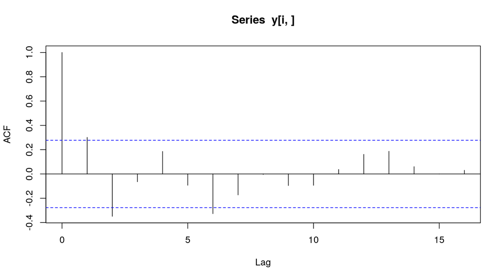

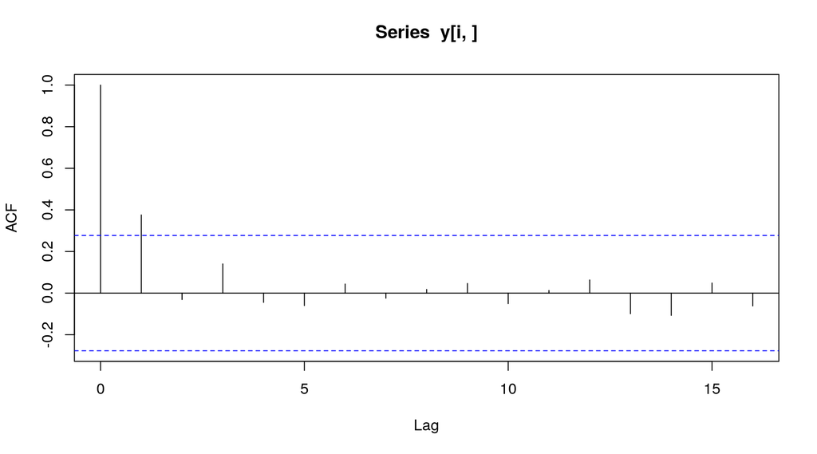

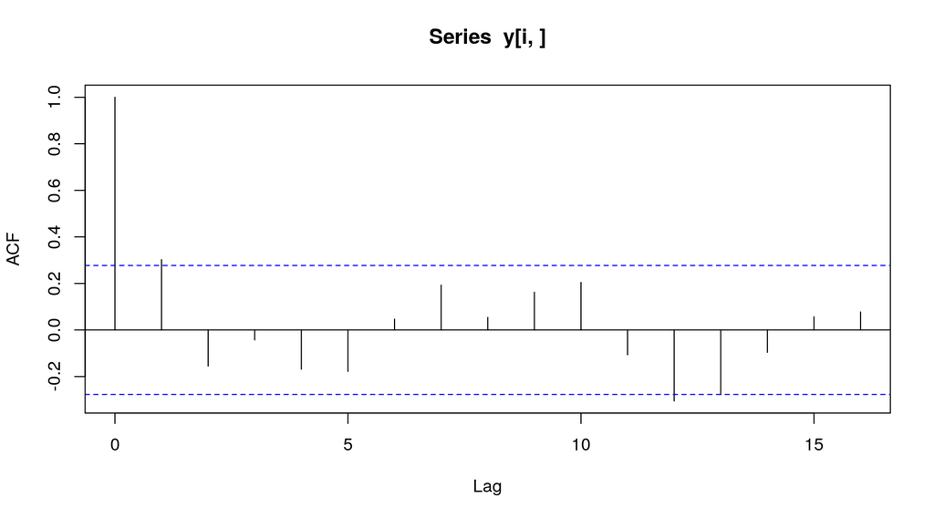

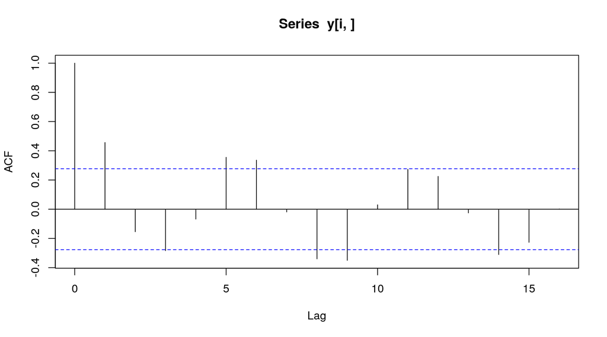

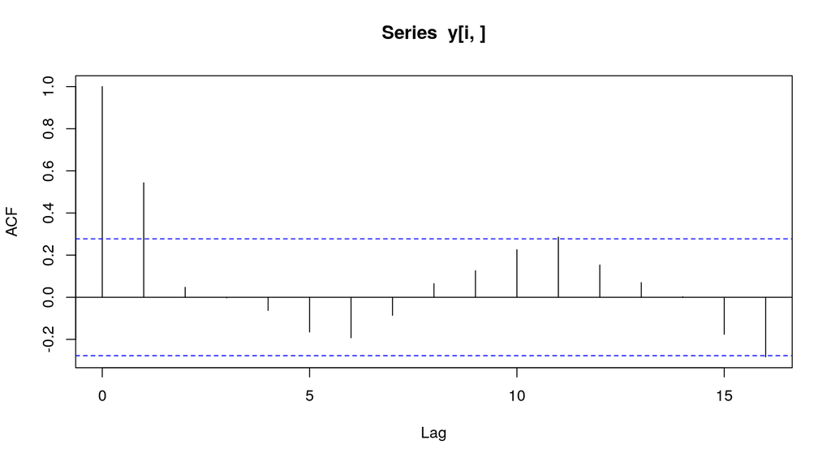

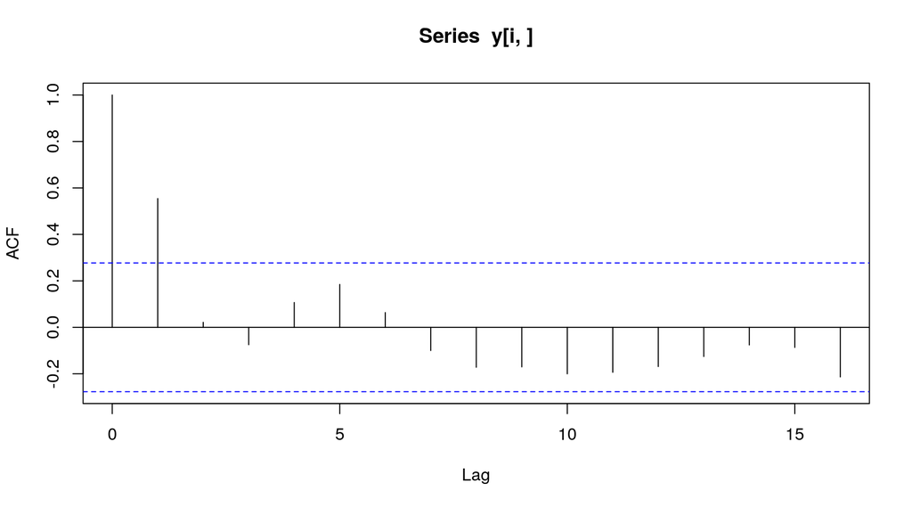

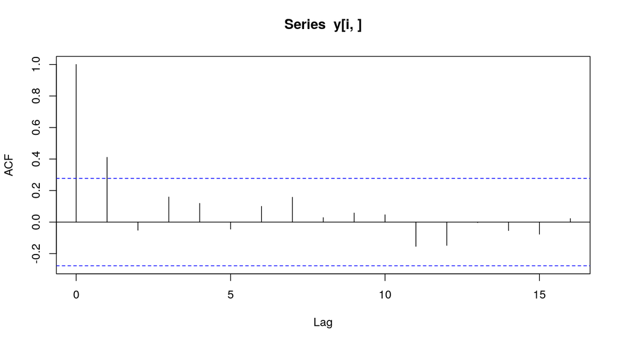

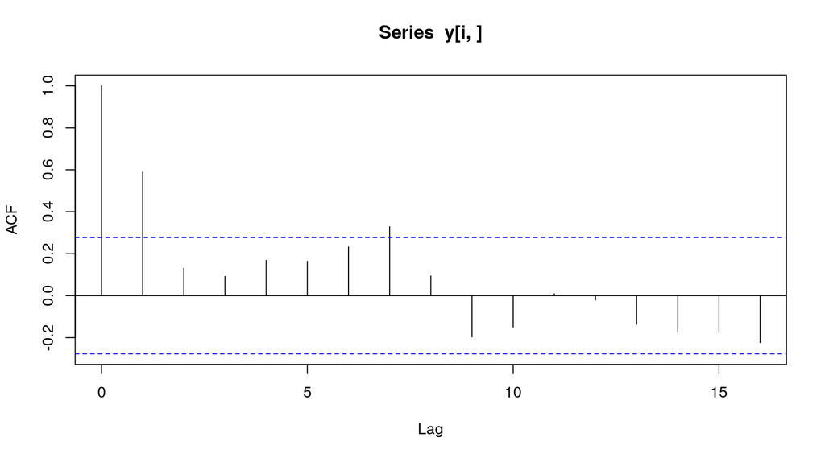

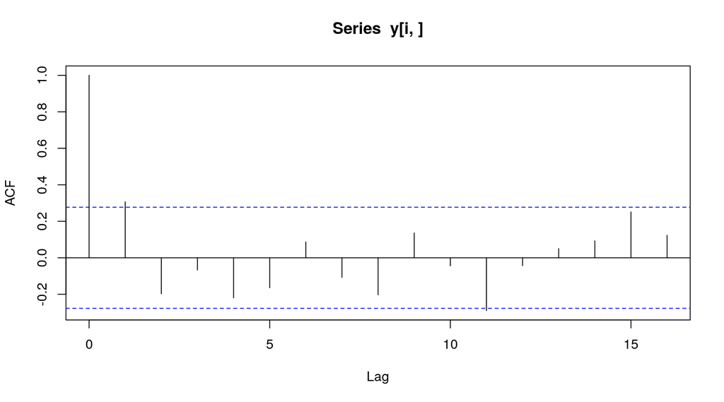

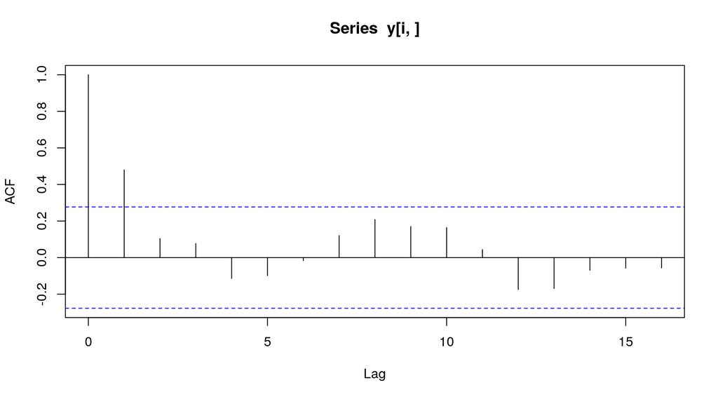

```r
for (i in 1:n) {
  acf(y[i, ])
}
```

## Exercise 7 cap 4

**Create a function that does the calculations in the first two lines of the previous exercise. Put the calculation in a loop that repeats 25 times. Calculate the mean and variance for each vector `y` that is returned. Store the 25 means in the vector `av`, and store the 25 variances in the vector `v`. Calculate the variance of `av`.**

```r
cor_data<-function(n = 51){
  y1 <- rnorm(n)
  return (y1[-1] + y1[-n])
}

av<-numeric(25)
v<- numeric(25)

for (i in 1:25){
  z<-cor_data()
  av[i]<- mean(z)
  v[i]<- var(z)
}
var(av)
```

```
## [1] 0.05983358
```

```r
#2 method
av1<-numeric(25)
v1<- numeric(25)
av1<-replicate(25,mean(cor_data()))
v1<-replicate(25,var(cor_data()))
var(av1)
```

```
## [1] 0.1526224
```

# CS exercises

## Exercise 3.3

**Rewrite the following, replacing the loop with efficient code:**

```r
original <-  function(n = 100000){
  z <- rnorm(n)
  zneg <- 0; j <- 1
  for (i in 1:n) {
    if (z[i]<0) {
      zneg[j] <- z[i]
      j <- j + 1
    }
  }
  return(zneg)
}

optimised <- function(n = 100000){
  return( Filter(function(el) el < 0, rnorm(n)) )
}

# Best solution -------------------------
optimised_v2 <-  function(n = 100000) {
  z <- rnorm(n)
  return( z[z < 0] )
}

print( "Original: " )
```

```
## [1] "Original: "
```

```r
system.time(original(10000000))
```

```
##    user  system elapsed
##   3.945   0.196   4.143
```

```r
print( "Optimised: " )
```

```
## [1] "Optimised: "
```

```r
system.time(optimised(10000000))
```

```
##    user  system elapsed
##   7.957   0.072   8.029
```

```r
print("Optimised v2: ")
```

```
## [1] "Optimised v2: "
```

```r
system.time(optimised_v2(10000000))
```

```
##    user  system elapsed
##   0.954   0.060   1.014
```

**Confirm that your rewrite is faster but gives the same result (use system.time()).**

We proceeded with two attemps, one with the function `Filter`, which failed as it resulted in a far worst performance that the original solution. Our solution is contained in the function `optimised_v2` by using the expression `z[z < 0]` which returns a new array with just the negative element of `z`

## Exercise 3.5

**Consider solving the matrix equation $Ax = y$ for $x$ , where $y$ is a known $n$ vector and $A$ is a known $n × n$ matrix. The formal solution to the problem is $x = A^{-1} y$ , but it is possible to solve the equation directly, without actually forming $A^{-1}$ . This question explores this direct solution. Read the help file for `solve` before trying it.**

**1. First create an $A$ , $x$ and $y$ satisfying $Ax = y$.**

```r
set.seed(0); n <- 1000
A <- matrix(runif(n*n),n,n); x.true <- runif(n)
y <- A%*%x.true
```

**The idea is to experiment with solving $Ax = y$ for $x$ , but with a known truth to compare the answer to.**

**2. Using `solve` , form the matrix $A^{−1}$ explicitly and then form $x_1 = A^{−1}y$ . Note how long this takes. Also assess the mean absolute differ- ence between $x1$ and $x.true$ (the approximate mean absolute ‘error’ in the solution).**

**3. Now use solve to directly solve for $x$ without forming $A^-1$ . Note how long this takes and assess the mean absolute error of the result.**

**4. What do you conclude?**

```r
library(dplyr)
set.seed(0)
n <- 1000
A <- matrix(runif(n*n),n,n)
x.true <- runif(n)
y <- A %*% x.true

manual <- function(A, xTrue, y) {
  A_inv <- solve(A)
  x <- A_inv %*% y
  mean(abs(x-x.true)) %>% print
  return(x)
}

auto <- function(A, xTrue, y){
  x <- solve(A,y)
  mean(abs(x-x.true)) %>% print
  return(x)
}

system.time(manual(A, x.true, y))
```

```
## [1] 2.974998e-11
```

```
##    user  system elapsed
##   0.412   0.076   0.132
```

```r
system.time(auto(A, x.true, y))
```

```
## [1] 7.835603e-13
```

```
##    user  system elapsed
##   0.168   0.028   0.053
```

We can conclude that computing the inverse matrix $A^{-1}$ and then explicitly find $x_1$ is less time efficient and results in a greter error when compared with using to directly solve for $x$ without computing the inverse matrix.